# phylorug

[figure not shown]

**phylorug** is an R package for comparing and visualizing clade recovery and support values across multiple phylogenetic trees on a single reference topology using rug plots. Modern phylogenomic studies routinely produce trees from different inference pipelines — concatenation versus coalescent methods, site-homogeneous versus site-heterogeneous substitution models, different data filtering strategies — each with support values in incompatible formats (ultrafast bootstrap, SH-aLRT, posterior probability, local posterior probability). **phylorug** maps all of these onto one tree, letting the researcher see at a glance which nodes are robust across methods and which are not.

### Presence mode

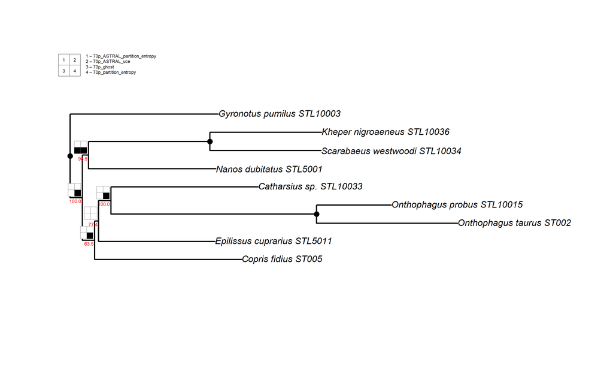

Presence mode

### Support mode

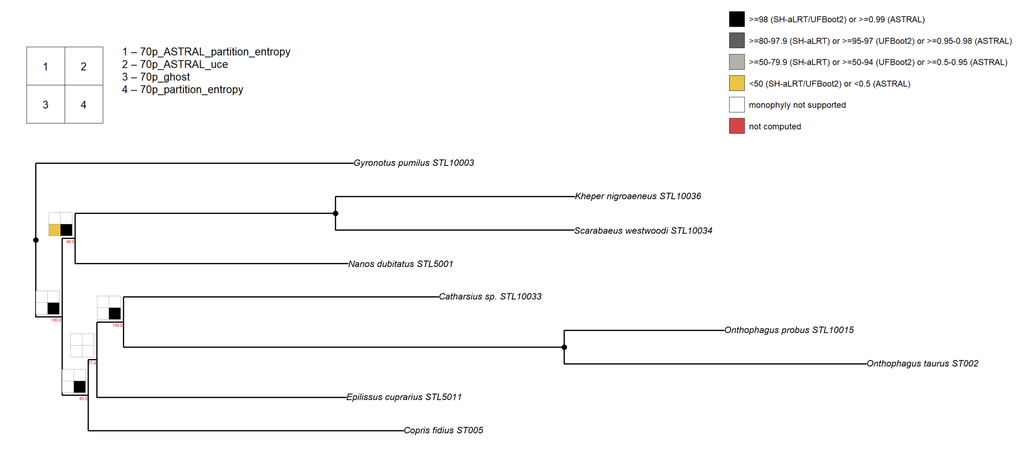

Support mode

### Installation

**phylorug** is not yet on CRAN. To install the development version from GitHub:

```r
# install.packages("devtools")
devtools::install_github("mdrifathahamed/phylorug")
library(phylorug)
```

### Quick example

```r
library(phylorug)

# Load bundled example trees
data(sample_trees)

# Build the node presence matrix
npm <- node_presence_matrix(sample_trees)

# Presence mode
plot_phylorug(npm, mode = "presence")

# Support mode
plot_phylorug(npm, mode = "support",
              support_type = c("ufboot", "ufboot", "posterior",
                               "ufboot", "lpp"))
```

**Presence mode** shows whether each analysis recovers a given clade (black = recovered, white = not recovered). This is the direct descendant of the “Navajo rug” plots introduced by Wheeler (1995) and formalized by Giribet (2003).

### Features

- Reads Newick and Nexus tree files via `read_trees()`
- Handles compound IQ-TREE labels (e.g. `SH-aLRT/UFBoot2`)
- Translates tip labels between naming conventions with `translate_tips()`
- Prunes to shared taxa across analyses with `prune_to_shared()`
- Validates taxon overlap with `check_taxa()`
- Treats a bare `multiPhylo` as one analysis (a pool of tied-optimal trees)
- Explicit errors over silent failures throughout

### Dependencies

**phylorug** depends on ape and phangorn. No other external dependencies are required.

### Help

An overview of the package with links to all function documentation:

```r
?phylorug
```

### Getting help

If you find a bug or have a feature request, please open an issue on [GitHub](https://github.com/mdrifathahamed/phylorug/issues).

### Citation

If you use **phylorug** in a publication, please cite:

> Ahamed, M.R., Tarasov, S., and Arias, J.S. (2026). phylorug: Visualize Clade Recovery and Support Across Phylogenetic Trees. R package version 0.1.0. https://github.com/mdrifathahamed/phylorug

### Acknowledgements

This package was developed at the [Finnish Museum of Natural History (LUOMUS)](https://www.luomus.fi/en), University of Helsinki, as part of an MSc thesis in Ecology and Evolutionary Biology under the supervision of Dr. Sergei Tarasov.

The rug-plot concept for phylogenetic sensitivity analysis traces to Wheeler (1995), was formalized by Giribet (2003), and automated by Sanders (2010, Cladescan) and Machado (2015, YBYRÁ).